# Landscape and Diversity

OK, there is a level of complexity in the data that we are foundering in. I think we need to step back and take a slightly more complete view of what is going on and rely upon the things that we have access to.

Our goal here is to ask the following question:

> How does ecological context/urban position influence connectivity in an understory tree?

There are several facets of this and I think we can take them sequentially. I’m going to use the complete data set as an example to walk through this but we’ll want to do this for the rest of the data as well. I’m using your data assuming that the file `Families_edited.csv` (dated last modified 9 June 2021) is the proper data file to work with. Your GoogleDrive file is a bit messed up for reasons I cannot understand and it is not treating it as a CSV file (Excel cruft?). I downloaded a local copy.

```r
df <- read_population( "data/Families_edited.csv", type="separated", locus.columns=7:15)
summary( df )
```

```
      ID               OffID             DNA_type             type             longitude         latitude
 Length:996         Length:996         Length:996         Length:996         Min.   :-77.59   Min.   :37.35
 Class :character   Class :character   Class :character   Class :character   1st Qu.:-77.54   1st Qu.:37.39
 Mode  :character   Mode  :character   Mode  :character   Mode  :character   Median :-77.51   Median :37.43
                                                                             Mean   :-77.51   Mean   :37.43
                                                                             3rd Qu.:-77.47   3rd Qu.:37.48
                                                                             Max.   :-77.44   Max.   :37.52

      cf020          cf125          cf213          cf273          cf581          cf585          cf597
 120:134 : 52   153:155 :247   136:148 : 20   138:138 :382   232:232 :740   171:171 : 59   107:91  : 55
 120:138 : 50   153:153 :175   132:136 : 18   134:138 :194   222:232 :109   169:171 : 50   109:91  : 43
 120:136 : 49   153:157 :160   122:142 : 17   126:138 : 61   224:232 : 49   167:171 : 41   107:107 : 42
 120:120 : 38   155:157 :136   124:140 : 14   136:138 : 40   232:236 : 38   171:181 : 41   107:109 : 41
 134:134 : 38   155:155 : 89   140:140 : 14   138:140 : 36   224:224 :  9   169:181 : 35   91:91   : 38
 (Other) :717   (Other) :112   (Other) :796   (Other) :254   (Other) : 29   (Other) :708   (Other) :650
 NA's    : 52   NA's    : 77   NA's    :117   NA's    : 29   NA's    : 22   NA's    : 62   NA's    :127
      cf634          cf701
 104:108 :105   128:128 :157
 104:118 : 77   114:128 :114
 104:106 : 76   120:128 : 79
 104:104 : 72   126:128 : 75
 106:108 : 52   124:128 : 61
 (Other) :574   (Other) :460
 NA's    : 40   NA's    : 50
```

## Plot the Locations

First things first, lets get an idea of where these individuals are located.

```r
df %>%
  filter( OffID == "0") %>%
  st_as_sf( coords=c("longitude","latitude"), crs=4326 ) -> moms

moms %>%
  leaflet() %>%
  addCircles( color="red") %>%
  addProviderTiles( provider = providers$Stamen.Terrain)
```

[interactive chart not shown]

```r
NA
```

So now, we should look to see if there are features of the surrounding landscape that influence the diversity of pollen reaching a maternal tree.

### Main Spatial Axis

Before I do this, I’m going to define a new variable representing the main spatial axis along which your data are arrayed. Then we can look at how the varialbes we are looking at change sytematically along that axis.

```r
df %>%
  filter( OffID == "0") %>%
  select( longitude, latitude ) %>%
  princomp() -> pcfit

moms$MainAxis <- pcfit$scores[,1]
```

Now, we can look at pollen pool diversity using effective allelic diversity, make it a wide `data.frame`, and then merge in the maternal locations.

```r
pollen <- minus_mom( df )
pollen %>%
  genetic_diversity(stratum="ID") %>%
  merge( moms %>% select(Stratum = ID, MainAxis, geometry) ) %>%
  select( Stratum, MainAxis, everything() ) %>%
  mutate( Locus = factor( Locus) ) -> df.pollenDiversity

head( df.pollenDiversity )
```

|  | Stratum | MainAxis | Locus | Ae | geometry |
| --- | --- | --- | --- | --- | --- |
| 1 | 1024PWP | -0.104541 | cf273 | 2.227723 |  |
| 2 | 1024PWP | -0.104541 | cf585 | 6.720930 |  |
| 3 | 1024PWP | -0.104541 | cf634 | 3.142857 |  |
| 4 | 1024PWP | -0.104541 | cf581 | 1.717557 |  |
| 5 | 1024PWP | -0.104541 | cf020 | 5.897959 |  |
| 6 | 1024PWP | -0.104541 | cf125 | 2.828877 |  |

Now, we can plot the diversity as a function of axis location

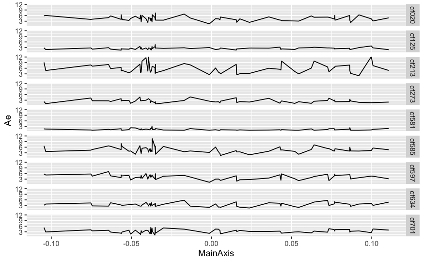

```r
df.pollenDiversity %>%
  ggplot( ) +
  geom_line( aes( MainAxis, Ae)) +
  facet_grid(Locus ~ . )
```

So spatially, there seems to be lots of variation but not systematically arranged as a clear gradient. If we wanted to look at any one of the locus correlations as well as the sum of all `Ae` values, we can make this output.

```r
df.pollenDiversity %>%
  spread( Locus, Ae ) -> df

df.table <- data.frame( Locus = names( df)[4:12],
                        Correlation = NA,
                        P = NA
)
for( locus in df.table$Locus ) {

  if( any(is.infinite(df[[locus]]))) {
    df[[locus]][is.infinite(df[[locus]])] <- NA

  }

  fit <- cor.test( df$MainAxis,
                   df[[locus]],
                   na.rm=TRUE)



  df.table$Correlation[ df.table$Locus == locus ] <- fit$estimate
  df.table$P[ df.table$Locus == locus ] <- fit$p.value
}

df.pollenDiversity %>%
  group_by( Stratum ) %>%
  summarize( MainAxis = mean( MainAxis),
             Diversity = sum( Ae )) %>%
  filter( !is.infinite(Diversity) ) -> df

cor.test( df$MainAxis, df$Diversity, na.rm=TRUE) -> fit.all

rbind( df.table, data.frame( Locus = "Multilocus",
                             Correlation = fit.all$estimate,
                             P = fit.all$p.value )) %>%
  kable( caption = "Correlation of single locus estimates for effective allelic pollen pool diversity along main spatial axis.",
         digits = 4,
         row.names = FALSE) %>%
  kable_paper() %>%
  kable_styling( full_width = FALSE)
```

Correlation of single locus estimates for effective allelic pollen pool diversity along main spatial axis.

| Locus | Correlation | P |
| --- | --- | --- |
| cf020 | -0.1369 | 0.2929 |
| cf125 | 0.0619 | 0.6357 |
| cf213 | -0.1075 | 0.4179 |
| cf273 | -0.1103 | 0.3973 |
| cf581 | -0.1635 | 0.2080 |
| cf585 | -0.1350 | 0.2996 |
| cf597 | -0.1839 | 0.1559 |
| cf634 | 0.1833 | 0.1573 |
| cf701 | 0.0755 | 0.5630 |
| Multilocus | -0.1259 | 0.3422 |

```r
NA
```

OK, so no overall systematic change in observed diversity at a locus ‘spatially’ along the main axis of sampling. This is probably something that is not that surprising, since the gradient in urbanness is probalby not aligned perfectly with the main spatial axis.

### At Site Diversity - The Reesponses

First, I’ll take the pollen polls and reduce them to a single vector based upon allele frequencies and then do a simple rotation to project it into a lower dimensional space.

```r
pollen %>%
  to_mv() %>%
  princomp( cor=TRUE ) -> fit.pca
```

Let’s take a look at the loadings for each axis we see that we have 142 independently assorting alleles in this data set (across all loci).

```r
summary( fit.pca )
```

```
Importance of components:
                           Comp.1     Comp.2     Comp.3     Comp.4     Comp.5     Comp.6     Comp.7     Comp.8
Standard deviation     1.75913778 1.53143410 1.49740813 1.45817884 1.43207507 1.42244009 1.39863166 1.38863704
Proportion of Variance 0.02179272 0.01651613 0.01579036 0.01497384 0.01444253 0.01424884 0.01377585 0.01357967
Cumulative Proportion  0.02179272 0.03830885 0.05409921 0.06907305 0.08351558 0.09776442 0.11154027 0.12511994
                           Comp.9    Comp.10    Comp.11    Comp.12    Comp.13    Comp.14    Comp.15    Comp.16
Standard deviation     1.36967000 1.35149536 1.33928356 1.33370080 1.32564492 1.30585662 1.30388651 1.29699314
Proportion of Variance 0.01321124 0.01286296 0.01263155 0.01252646 0.01237559 0.01200888 0.01197268 0.01184642
Cumulative Proportion  0.13833117 0.15119413 0.16382568 0.17635215 0.18872774 0.20073662 0.21270930 0.22455572
                          Comp.17    Comp.18    Comp.19    Comp.20    Comp.21    Comp.22    Comp.23    Comp.24
Standard deviation     1.28244484 1.27996860 1.26331078 1.25741368 1.25037097 1.24105930 1.23687368 1.23182536
Proportion of Variance 0.01158215 0.01153746 0.01123911 0.01113443 0.01101005 0.01084668 0.01077364 0.01068587
Cumulative Proportion  0.23613786 0.24767533 0.25891444 0.27004887 0.28105892 0.29190560 0.30267924 0.31336511
                          Comp.25    Comp.26    Comp.27    Comp.28     Comp.29    Comp.30    Comp.31     Comp.32
Standard deviation     1.22236574 1.21473244 1.21195144 1.19878746 1.190974409 1.18453443 1.17486458 1.169720518
Proportion of Variance 0.01052238 0.01039137 0.01034385 0.01012036 0.009988874 0.00988114 0.00972047 0.009635536
Cumulative Proportion  0.32388749 0.33427886 0.34462271 0.35474307 0.364731945 0.37461308 0.38433356 0.393969091
                           Comp.33     Comp.34     Comp.35    Comp.36     Comp.37     Comp.38     Comp.39     Comp.40
Standard deviation     1.166671813 1.164810987 1.148822785 1.14649961 1.141825378 1.139791068 1.137464815 1.127716878
Proportion of Variance 0.009585374 0.009554821 0.009294322 0.00925677 0.009181445 0.009148758 0.009111452 0.008955953
Cumulative Proportion  0.403554465 0.413109287 0.422403609 0.43166038 0.440841824 0.449990583 0.459102035 0.468057988
                           Comp.41     Comp.42     Comp.43     Comp.44     Comp.45     Comp.46    Comp.47     Comp.48
Standard deviation     1.121779709 1.114742152 1.111441931 1.105090534 1.097421419 1.091297540 1.08674074 1.083311187
Proportion of Variance 0.008861899 0.008751057 0.008699318 0.008600177 0.008481224 0.008386833 0.00831694 0.008264529
Cumulative Proportion  0.476919887 0.485670944 0.494370262 0.502970439 0.511451663 0.519838496 0.52815544 0.536419965
                           Comp.49     Comp.50     Comp.51     Comp.52     Comp.53     Comp.54     Comp.55     Comp.56
Standard deviation     1.075617291 1.070098052 1.070034833 1.064853737 1.056624706 1.054907266 1.049615093 1.040215851
Proportion of Variance 0.008147553 0.008064154 0.008063201 0.007985306 0.007862365 0.007836826 0.007758393 0.007620064
Cumulative Proportion  0.544567518 0.552631672 0.560694873 0.568680179 0.576542543 0.584379370 0.592137763 0.599757827
                           Comp.57     Comp.58     Comp.59    Comp.60     Comp.61     Comp.62     Comp.63     Comp.64
Standard deviation     1.037020966 1.035266174 1.025149571 1.02043210 1.017430379 1.014744482 1.012849085 1.009136817
Proportion of Variance 0.007573327 0.007547719 0.007400927 0.00733297 0.007289891 0.007251453 0.007224389 0.007171529
Cumulative Proportion  0.607331154 0.614878873 0.622279800 0.62961277 0.636902661 0.644154114 0.651378503 0.658550032
                           Comp.65     Comp.66     Comp.67     Comp.68    Comp.69     Comp.70     Comp.71     Comp.72
Standard deviation     1.000923591 0.995167980 0.994069322 0.986834787 0.98416777 0.979709613 0.975313336 0.972223687
Proportion of Variance 0.007055268 0.006974361 0.006958971 0.006858049 0.00682103 0.006759373 0.006698846 0.006656471
Cumulative Proportion  0.665605300 0.672579661 0.679538632 0.686396680 0.69321771 0.699977083 0.706675928 0.713332400
                           Comp.73     Comp.74     Comp.75     Comp.76     Comp.77     Comp.78     Comp.79     Comp.80
Standard deviation     0.967840255 0.960474490 0.953610302 0.948268527 0.942331348 0.937195625 0.931829491 0.927500176
Proportion of Variance 0.006596583 0.006496558 0.006404032 0.006332487 0.006253439 0.006185462 0.006114832 0.006058145
```

[output cut: 18 more lines]

```
Standard deviation     0.748270172 0.741810898 0.72796860 0.723270825 0.721057326 0.71880437 0.7069233 0.696632410
Proportion of Variance 0.003943016 0.003875235 0.00373196 0.003683948 0.003661434 0.00363859 0.0035193 0.003417582
Cumulative Proportion  0.928675046 0.932550281 0.93628224 0.939966189 0.943627623 0.94726621 0.9507855 0.954203095
                          Comp.121    Comp.122    Comp.123    Comp.124    Comp.125    Comp.126    Comp.127    Comp.128
Standard deviation     0.682365611 0.679334438 0.671144140 0.666838863 0.658327840 0.646132924 0.642086500 0.634544914
Proportion of Variance 0.003279034 0.003249967 0.003172074 0.003131508 0.003052081 0.002940055 0.002903346 0.002835544
Cumulative Proportion  0.957482129 0.960732096 0.963904170 0.967035677 0.970087758 0.973027813 0.975931159 0.978766703
                          Comp.129    Comp.130    Comp.131    Comp.132    Comp.133    Comp.134    Comp.135   Comp.136
Standard deviation     0.627027950 0.609997047 0.606615618 0.583709793 0.580808767 0.498703878 0.439556474 0.40733091
Proportion of Variance 0.002768761 0.002620397 0.002591426 0.002399416 0.002375626 0.001751448 0.001360633 0.00116844
Cumulative Proportion  0.981535464 0.984155861 0.986747287 0.989146703 0.991522329 0.993273776 0.994634409 0.99580285
                           Comp.137     Comp.138     Comp.139     Comp.140     Comp.141 Comp.142
Standard deviation     0.3723915151 0.3664663093 0.3464065125 0.3349494447 0.3013864645        0
Proportion of Variance 0.0009765876 0.0009457574 0.0008450526 0.0007900784 0.0006396747        0
Cumulative Proportion  0.9967794369 0.9977251943 0.9985702470 0.9993603253 1.0000000000        1
```

Each individual rotated axis explains an incrementally smaller amount of variation (though we probably could get away with much less thatn 142 predictors overall).

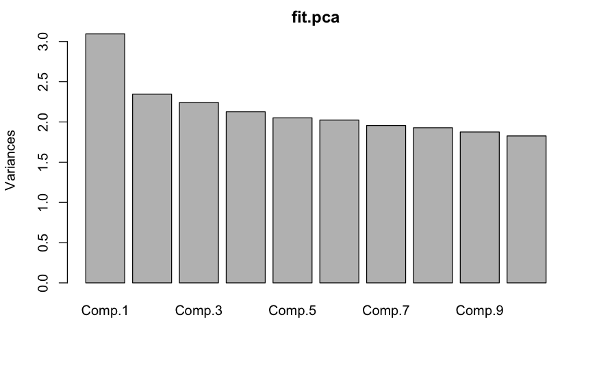

```r
plot( fit.pca )
```

So it looks like there is a smooth transition in pollen pool structure across the rotated axes. If we plot the moms in this new space, we see the following

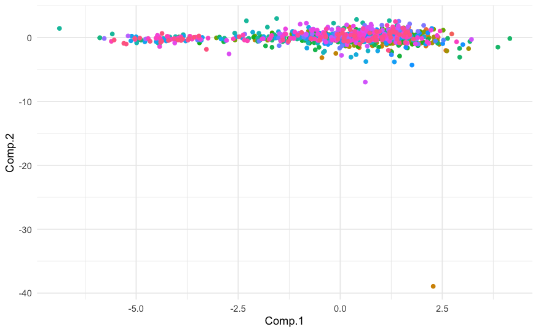

```r
predict( fit.pca ) %>%
  data.frame() %>%
  mutate( Stratum = pollen$ID ) -> df.pca

df.pca %>%
  ggplot( aes(Comp.1,Comp.2, color=Stratum) ) +
  geom_point( show_legend=FALSE) +
  theme_minimal() +
  scale_color_discrete( guide=FALSE)
```

Besides one outlier there does not seem to be any major issues. Just to ignore that one.

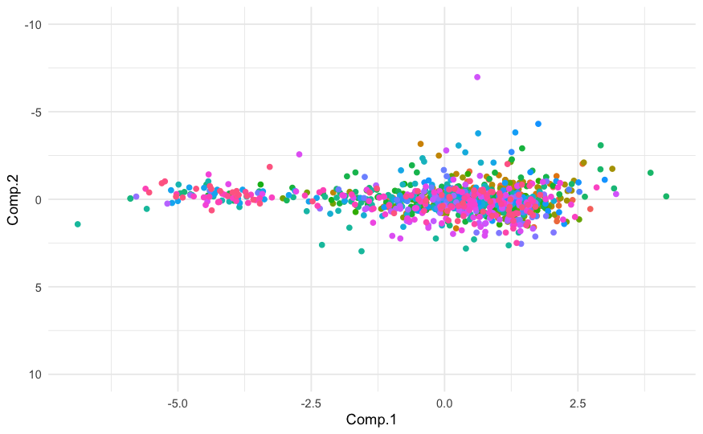

```r
df.pca %>%
  ggplot( aes(Comp.1,Comp.2, color=Stratum) ) +
  geom_point( show_legend=FALSE) +
  theme_minimal() +
  scale_color_discrete( guide=FALSE) +
  ylim( c(10,-10))
```

We can also reduce the dimensionality of the entire thing and look at it as a principal coordinates analysis (same data, just summarized at the level of the mom rahter than the individual)

```r
pollen %>%
  frequency_matrix(stratum = "ID") -> freqs
f <- as.matrix( freqs[ , c(2:ncol(freqs))])
rownames( f ) <- freqs$Stratum
fit.pcoa <- prcomp( f, center = TRUE )
summary( fit.pcoa )
```

```
Importance of components:
                          PC1     PC2     PC3     PC4     PC5     PC6     PC7    PC8     PC9    PC10    PC11    PC12
Standard deviation     0.3432 0.30057 0.26650 0.24848 0.24021 0.21921 0.21316 0.2061 0.19864 0.18758 0.17957 0.17367
Proportion of Variance 0.1065 0.08168 0.06421 0.05582 0.05217 0.04345 0.04108 0.0384 0.03568 0.03181 0.02915 0.02727
Cumulative Proportion  0.1065 0.18818 0.25240 0.30822 0.36039 0.40383 0.44491 0.4833 0.51899 0.55080 0.57995 0.60722
                         PC13    PC14    PC15    PC16    PC17    PC18    PC19    PC20   PC21   PC22    PC23    PC24
Standard deviation     0.1686 0.16079 0.15965 0.15461 0.15368 0.14628 0.14489 0.13898 0.1275 0.1253 0.12346 0.12049
Proportion of Variance 0.0257 0.02338 0.02304 0.02161 0.02135 0.01935 0.01898 0.01746 0.0147 0.0142 0.01378 0.01313
Cumulative Proportion  0.6329 0.65630 0.67934 0.70096 0.72231 0.74165 0.76063 0.77810 0.7928 0.8070 0.82077 0.83390
                         PC25   PC26    PC27    PC28    PC29    PC30    PC31    PC32    PC33    PC34    PC35    PC36
Standard deviation     0.1133 0.1088 0.10804 0.10581 0.10229 0.09827 0.09709 0.09105 0.09024 0.08827 0.08345 0.07925
Proportion of Variance 0.0116 0.0107 0.01055 0.01012 0.00946 0.00873 0.00852 0.00750 0.00736 0.00705 0.00630 0.00568
Cumulative Proportion  0.8455 0.8562 0.86676 0.87688 0.88634 0.89507 0.90360 0.91109 0.91846 0.92550 0.93180 0.93748
                          PC37    PC38    PC39    PC40    PC41    PC42    PC43    PC44    PC45    PC46    PC47    PC48
Standard deviation     0.07802 0.07579 0.07475 0.07131 0.06767 0.06682 0.06246 0.05994 0.05747 0.05647 0.05455 0.04973
Proportion of Variance 0.00550 0.00519 0.00505 0.00460 0.00414 0.00404 0.00353 0.00325 0.00299 0.00288 0.00269 0.00224
Cumulative Proportion  0.94298 0.94817 0.95323 0.95782 0.96196 0.96600 0.96953 0.97278 0.97576 0.97864 0.98134 0.98357
                          PC49    PC50    PC51    PC52    PC53    PC54    PC55    PC56    PC57    PC58    PC59    PC60
Standard deviation     0.04729 0.04630 0.04380 0.04180 0.04094 0.03951 0.03603 0.03428 0.03123 0.02996 0.02906 0.02642
Proportion of Variance 0.00202 0.00194 0.00173 0.00158 0.00152 0.00141 0.00117 0.00106 0.00088 0.00081 0.00076 0.00063
Cumulative Proportion  0.98559 0.98753 0.98927 0.99085 0.99236 0.99377 0.99495 0.99601 0.99689 0.99770 0.99847 0.99910
                          PC61    PC62      PC63
Standard deviation     0.02367 0.02095 1.524e-16
Proportion of Variance 0.00051 0.00040 0.000e+00
Cumulative Proportion  0.99960 1.00000 1.000e+00
```

Then look at where individual mothers come out.

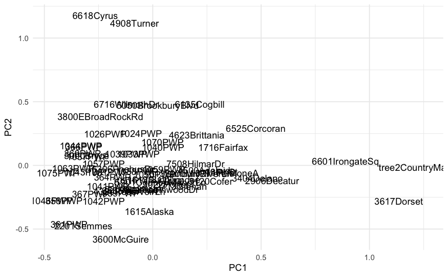

```r
predict( fit.pcoa ) %>%
  data.frame() %>%
  mutate( Stratum = freqs$Stratum ) %>%
  ggplot( aes(PC1,PC2) ) +
  geom_text( aes(label=Stratum)) +
  theme_minimal()
```

To see what is loading on these axes we can use the `fviz_pca` function.

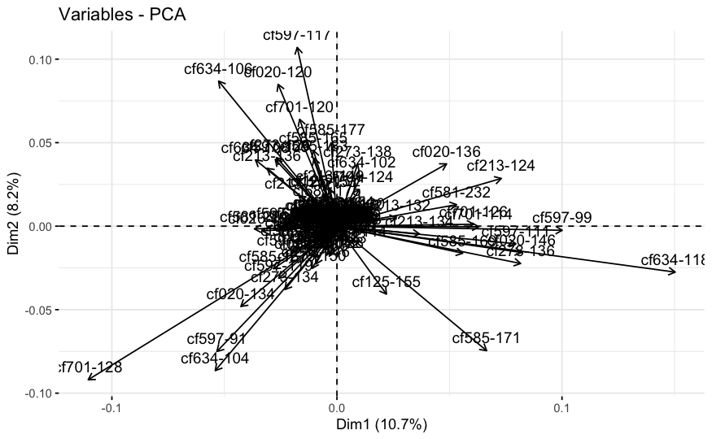

```r
library( factoextra )
fviz_pca_var( fit.pcoa )
```

So it looks like:

1. As a group of individuals, there are no obvious clustering (e.g., we have a single mixing population of samples).
2. As mothers, there are a few outer groups but in general there seems to be a good description of the genetic structure in either an *individual* based analysis of as *moms*.

This is good as it suggests that there is no reason we cannot use these rotated axes of pollen pool structure to see if they have a relationship with sets of at-site variables.

### At Site Diversity - Predictors

So now let’s grab all the predictor varialbes for `at-site` variablilty and see if there is anything intersting going on there. For this one, I’m using the data from the files `DF5_mom.csv`, `DF10_mom.csv`, and `DF50_mom.csv` and doing some tricky stuff

```r
loadAndFixNames <- function( file, size ) {
  read_csv( file, show_col_types = FALSE ) -> df
  df %>%
    gather( names(df)[2:ncol(df)], key = Feature, value = Value) %>%
    mutate( Feature = paste( Feature, size,sep=".")) %>%
    spread( Feature, Value )
}

loadAndFixNames(  "data/DF5m_mom.csv", 5 ) %>%
  merge( loadAndFixNames(  "data/DF10m_mom.csv", 10 ) ) %>%
  merge( loadAndFixNames(  "data/DF50m_mom.csv", 50 ) ) %>%
  mutate( Stratum = factor( mom ) ) %>%
  select( -mom, -total.5, -total.10, -total.50 ) %>%
  select( sort(names(.)) ) %>%
  select( Stratum, everything() ) -> df.atsite

summary( df.atsite)
```

```
    Stratum    alltrees.10      alltrees.5     alltrees.50    disturbed.10  disturbed.5  disturbed.50   forest.10
 1024PWP: 1   Min.   :  0.0   Min.   : 0.00   Min.   :   0   Min.   :0     Min.   :0    Min.   :0     Min.   :  0.0
 1026PWP: 1   1st Qu.:  1.0   1st Qu.: 0.00   1st Qu.:1450   1st Qu.:0     1st Qu.:0    1st Qu.:0     1st Qu.:  0.0
 1033PWP: 1   Median :128.0   Median :25.00   Median :3224   Median :0     Median :0    Median :0     Median :  0.0
 1037PWP: 1   Mean   :169.7   Mean   :39.06   Mean   :4853   Mean   :0     Mean   :0    Mean   :0     Mean   :134.5
 1038PWP: 1   3rd Qu.:361.0   3rd Qu.:81.00   3rd Qu.:8888   3rd Qu.:0     3rd Qu.:0    3rd Qu.:0     3rd Qu.:361.0
 1039PWP: 1   Max.   :361.0   Max.   :81.00   Max.   :9801   Max.   :0     Max.   :0    Max.   :0     Max.   :361.0
 (Other):57
    forest.5       forest.50       grass.10         grass.5         grass.50       height_m.10      height_m.5
 Min.   : 0.00   Min.   :   0   Min.   :  0.00   Min.   : 0.00   Min.   :   0.0   Min.   :2.600   Min.   :2.600
 1st Qu.: 0.00   1st Qu.:   0   1st Qu.:  0.00   1st Qu.: 0.00   1st Qu.:  24.5   1st Qu.:4.000   1st Qu.:4.000
 Median : 0.00   Median : 561   Median : 82.00   Median :20.00   Median :2673.0   Median :4.900   Median :4.900
 Mean   :31.24   Mean   :3624   Mean   : 91.54   Mean   :25.71   Mean   :2382.5   Mean   :5.171   Mean   :5.171
 3rd Qu.:81.00   3rd Qu.:8231   3rd Qu.:171.00   3rd Qu.:46.00   3rd Qu.:3884.5   3rd Qu.:6.050   3rd Qu.:6.050
 Max.   :81.00   Max.   :9801   Max.   :326.00   Max.   :81.00   Max.   :6694.0   Max.   :9.900   Max.   :9.900
                                                                                  NA's   :12      NA's   :12
  height_m.50    impervious.10     impervious.5   impervious.50       other.10    other.5     other.50
 Min.   :2.600   Min.   :  0.00   Min.   : 0.00   Min.   :   0.0   Min.   :0   Min.   :0   Min.   :   0.0
 1st Qu.:4.000   1st Qu.:  0.00   1st Qu.: 0.00   1st Qu.: 402.5   1st Qu.:0   1st Qu.:0   1st Qu.:   0.0
 Median :4.900   Median : 86.00   Median : 3.00   Median :2688.0   Median :0   Median :0   Median :   0.0
 Mean   :5.171   Mean   : 99.73   Mean   :16.22   Mean   :2411.5   Mean   :0   Mean   :0   Mean   : 134.2
 3rd Qu.:6.050   3rd Qu.:171.00   3rd Qu.:33.00   3rd Qu.:3987.5   3rd Qu.:0   3rd Qu.:0   3rd Qu.:   0.0
 Max.   :9.900   Max.   :332.00   Max.   :74.00   Max.   :7663.0   Max.   :0   Max.   :0   Max.   :2480.0
 NA's   :12
   pasture.10   pasture.5   pasture.50    shrub.10    shrub.5     shrub.50 total_basal_area_sqcm.10
 Min.   :0    Min.   :0   Min.   :0    Min.   :0   Min.   :0   Min.   :0   Min.   :   5.00
 1st Qu.:0    1st Qu.:0   1st Qu.:0    1st Qu.:0   1st Qu.:0   1st Qu.:0   1st Qu.:  46.75
 Median :0    Median :0   Median :0    Median :0   Median :0   Median :0   Median :  83.50
 Mean   :0    Mean   :0   Mean   :0    Mean   :0   Mean   :0   Mean   :0   Mean   : 218.22
 3rd Qu.:0    3rd Qu.:0   3rd Qu.:0    3rd Qu.:0   3rd Qu.:0   3rd Qu.:0   3rd Qu.: 312.50
 Max.   :0    Max.   :0   Max.   :0    Max.   :0   Max.   :0   Max.   :0   Max.   :1028.00
                                                                           NA's   :9
 total_basal_area_sqcm.5 total_basal_area_sqcm.50    tree.10           tree.5          tree.50        water.10
 Min.   :   5.00         Min.   :   5.00          Min.   :  0.00   Min.   : 0.000   Min.   :   0   Min.   :0
 1st Qu.:  46.75         1st Qu.:  46.75          1st Qu.:  0.00   1st Qu.: 0.000   1st Qu.:  66   1st Qu.:0
 Median :  83.50         Median :  83.50          Median :  0.00   Median : 0.000   Median :1219   Median :0
 Mean   : 218.22         Mean   : 218.22          Mean   : 35.24   Mean   : 7.825   Mean   :1229   Mean   :0
 3rd Qu.: 312.50         3rd Qu.: 312.50          3rd Qu.: 48.00   3rd Qu.: 3.000   3rd Qu.:2056   3rd Qu.:0
 Max.   :1028.00         Max.   :1028.00          Max.   :285.00   Max.   :81.000   Max.   :4284   Max.   :0
 NA's   :9               NA's   :9
    water.5     water.50
 Min.   :0   Min.   :   0.00
 1st Qu.:0   1st Qu.:   0.00
 Median :0   Median :   0.00
 Mean   :0   Mean   :  19.52
 3rd Qu.:0   3rd Qu.:   0.00
 Max.   :0   Max.   :1230.00
```

Let’s drop the columns that have no variation. We also have to pull out any columns with missing data (cannot invert via SVD with NA, Inf, or NaN). I opted to drop the columns rather then remove the trees since most of the missing data is from mom tree characteristics, not things that are around her.

```r
df.atsite %>%
  select( -water.10, -water.5,
          -pasture.5, -pasture.10, -pasture.50,
          -disturbed.5, -disturbed.10, -disturbed.50,
          -other.5, -other.10,
          -shrub.5, -shrub.10, -shrub.50,
          -height_m.5, -height_m.10, -height_m.50,
          -total_basal_area_sqcm.5, -total_basal_area_sqcm.10, -total_basal_area_sqcm.50) -> df

summary( df )
```

```
    Stratum    alltrees.10      alltrees.5     alltrees.50     forest.10        forest.5       forest.50
 1024PWP: 1   Min.   :  0.0   Min.   : 0.00   Min.   :   0   Min.   :  0.0   Min.   : 0.00   Min.   :   0
 1026PWP: 1   1st Qu.:  1.0   1st Qu.: 0.00   1st Qu.:1450   1st Qu.:  0.0   1st Qu.: 0.00   1st Qu.:   0
 1033PWP: 1   Median :128.0   Median :25.00   Median :3224   Median :  0.0   Median : 0.00   Median : 561
 1037PWP: 1   Mean   :169.7   Mean   :39.06   Mean   :4853   Mean   :134.5   Mean   :31.24   Mean   :3624
 1038PWP: 1   3rd Qu.:361.0   3rd Qu.:81.00   3rd Qu.:8888   3rd Qu.:361.0   3rd Qu.:81.00   3rd Qu.:8231
 1039PWP: 1   Max.   :361.0   Max.   :81.00   Max.   :9801   Max.   :361.0   Max.   :81.00   Max.   :9801
 (Other):57
    grass.10         grass.5         grass.50      impervious.10     impervious.5   impervious.50       other.50
 Min.   :  0.00   Min.   : 0.00   Min.   :   0.0   Min.   :  0.00   Min.   : 0.00   Min.   :   0.0   Min.   :   0.0
 1st Qu.:  0.00   1st Qu.: 0.00   1st Qu.:  24.5   1st Qu.:  0.00   1st Qu.: 0.00   1st Qu.: 402.5   1st Qu.:   0.0
 Median : 82.00   Median :20.00   Median :2673.0   Median : 86.00   Median : 3.00   Median :2688.0   Median :   0.0
 Mean   : 91.54   Mean   :25.71   Mean   :2382.5   Mean   : 99.73   Mean   :16.22   Mean   :2411.5   Mean   : 134.2
 3rd Qu.:171.00   3rd Qu.:46.00   3rd Qu.:3884.5   3rd Qu.:171.00   3rd Qu.:33.00   3rd Qu.:3987.5   3rd Qu.:   0.0
 Max.   :326.00   Max.   :81.00   Max.   :6694.0   Max.   :332.00   Max.   :74.00   Max.   :7663.0   Max.   :2480.0

    tree.10           tree.5          tree.50        water.50
 Min.   :  0.00   Min.   : 0.000   Min.   :   0   Min.   :   0.00
 1st Qu.:  0.00   1st Qu.: 0.000   1st Qu.:  66   1st Qu.:   0.00
 Median :  0.00   Median : 0.000   Median :1219   Median :   0.00
 Mean   : 35.24   Mean   : 7.825   Mean   :1229   Mean   :  19.52
 3rd Qu.: 48.00   3rd Qu.: 3.000   3rd Qu.:2056   3rd Qu.:   0.00
 Max.   :285.00   Max.   :81.000   Max.   :4284   Max.   :1230.00
```

Now, lets look at the PC scores for the frist two dimenstions of the ecological data.

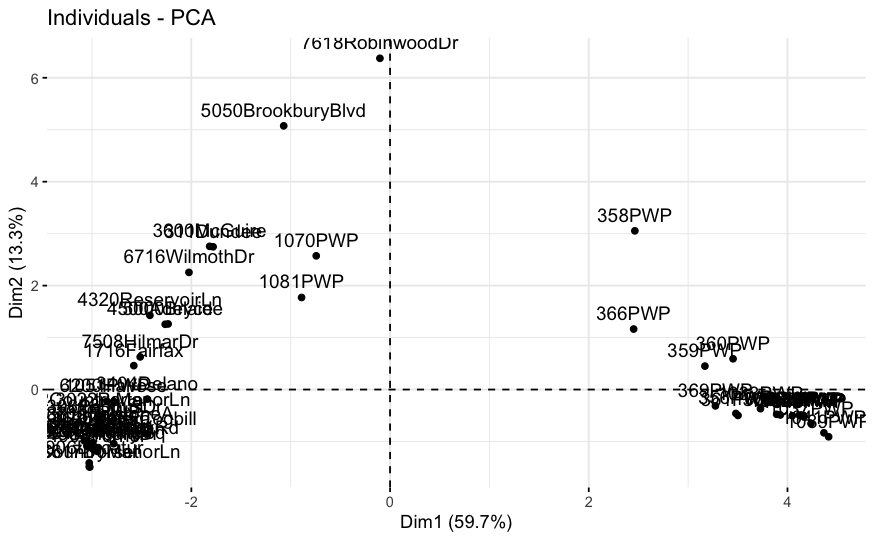

```r
raw <- as.matrix( df[,2:ncol(df)] )
rownames( raw ) <- df$Stratum
pcfit.atsite <- princomp( raw, cor=TRUE )
fviz_pca_ind( pcfit.atsite )
```

So, this is not an uncommon U-shaped patter we typically see. Most of hte PWP stuff seems clustered on one side. OK.

Let’s see what is loading on this separation.

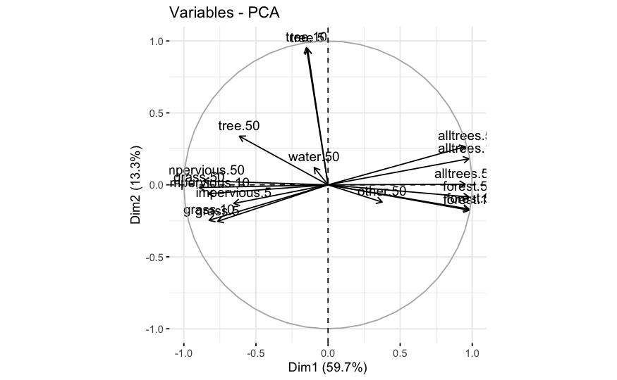

```r
fviz_pca_var( pcfit.atsite )
```

Not too surprsing.

### Putting it All Together

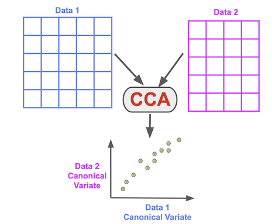

First, we must make sure that the order of the mothers is the same in both frequency and environmental data.

```r
Y <- predict( princomp(df.atsite[, 2:ncol(df.atsite)], cor=TRUE) )
```

[output not shown]